# HW 2 EDAV

Abhay Pawar(asp2197)

```r
library(vcdExtra)
library(ggplot2)
library(bayesm)
library(reshape2)
library(dplyr)
library(flexmix)
library(extracat)
library(nnet)
```

# Chapter 4, Question 5

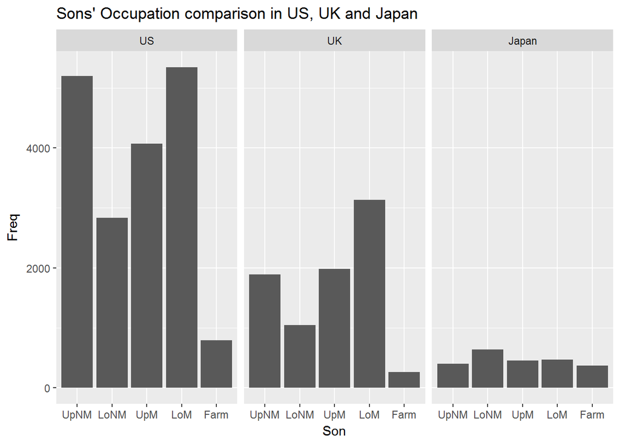

```r
#5.a
ggplot(data=Yamaguchi87,aes(x=Son,y=Freq))+geom_bar(stat='identity')+facet_wrap(~Country)+ ggtitle("Sons' Occupation comparison in US, UK and Japan")
```

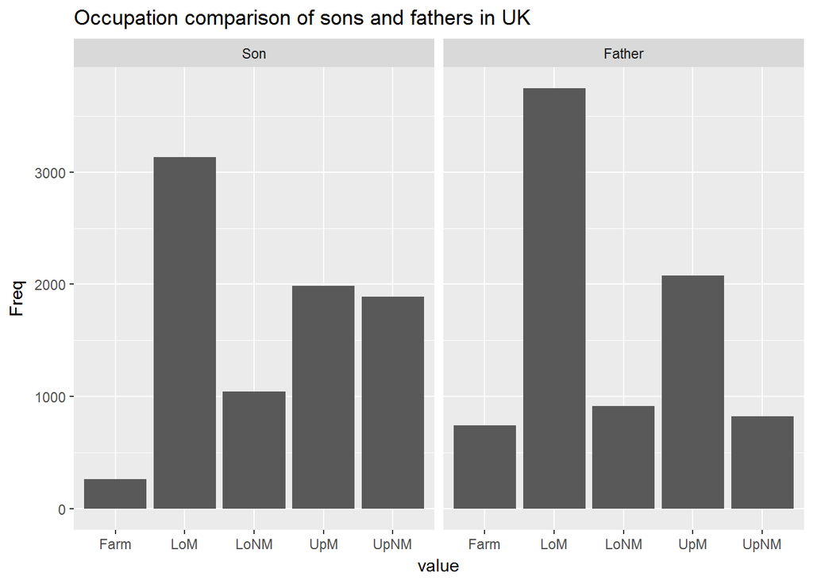

```r
#5.b
Yamaguchi87_tidy <- melt(Yamaguchi87, id=c("Country","Freq"))
ggplot(data=Yamaguchi87_tidy[Yamaguchi87$Country=='UK',],aes(x=value,y=Freq))+geom_bar(stat='identity')+facet_wrap(~variable)+ggtitle("Occupation comparison of sons and fathers in UK")
```

1. The distribution of occupations of Sons is somewhat similar in US and UK. It follows similar pattern in both countries except for the UpNM category. Japan looks completely different from US and UK.
2. We see that sons’ occupation is more skewed towards Non Manual job (especially UpNM). It can be said that sons usually move towards white collar jobs (NM). We also see more fathers in farming and manual occupations.
3. The results are what I expected. With modernization more people move towards white collar jobs which we can clearly see happening here.

# Chapter 4, Question 6

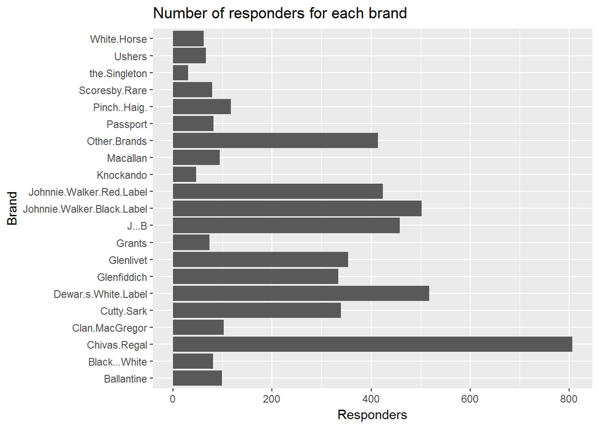

```r
data(Scotch)
per_brand=array(dim=21)
for (i in 1:21){
  per_brand[i]=sum(Scotch[,i])
}
data=matrix(nrow=1,ncol=2)
data=data.frame(data)
colnames(data)=c("Brand","Responders")
for (i in 1:21){
  data[i,1]=colnames(Scotch)[i]
  data[i,2]=per_brand[i]
}

brand_orderdesc <- data %>% arrange(desc(Responders))
data1=data
data1$Brand<-factor(data1$Brand,levels=brand_orderdesc$Brand)
ggplot(data=data,aes(x=Brand,y=Responders))+geom_bar(stat='identity')+ coord_flip()+ggtitle("Number of responders for each brand")
```

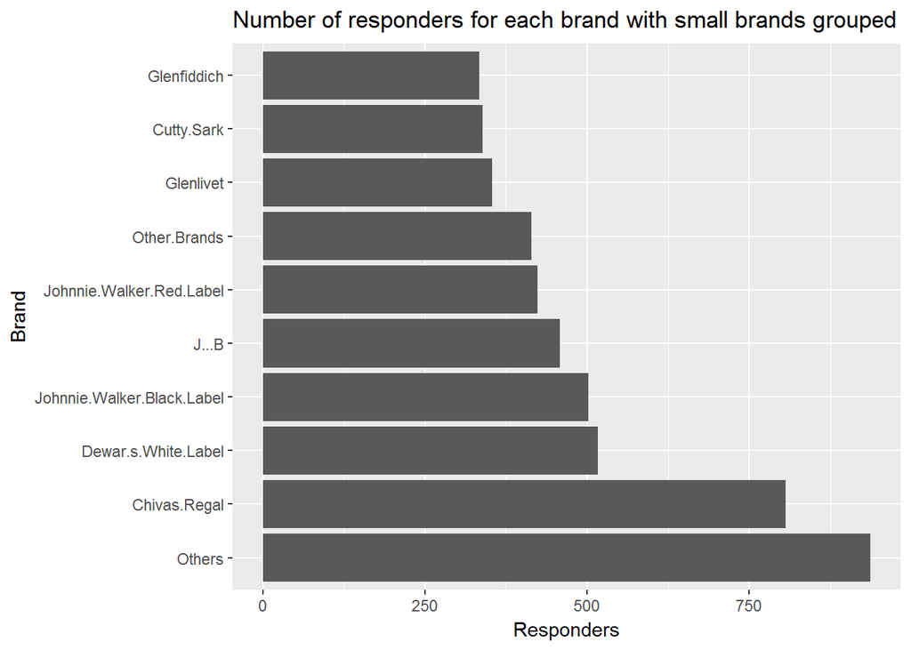

```r
#6 (b)
Others=data[1:10,]
Others$Brand[10]="Others"
Others$Responders[10]=sum(data$Responders[10:length(data$Responders)])
brand_orderdesc1 <- Others %>% arrange(desc(Responders))
data2=Others
data2$Brand<-factor(Others$Brand,levels=brand_orderdesc1$Brand)
ggplot(data=data2,aes(x=Brand,y=Responders))+geom_bar(stat='identity')+ coord_flip()+ggtitle("Number of responders for each brand with small brands grouped")
```

```r
#6 (c)
data(whiskey)
write.csv(whiskey_brands,"whiskey_brands.csv")
write.csv(data1,"responders.csv")
#Putting whiskey brands data in responders dataset. Used excel for this because the names werent exactly same in both datasets.
library(readr)
responders <- read_csv("G:/Acads/EDAV/responders_extra.csv",
    col_types = cols(X1 = col_skip()))
```

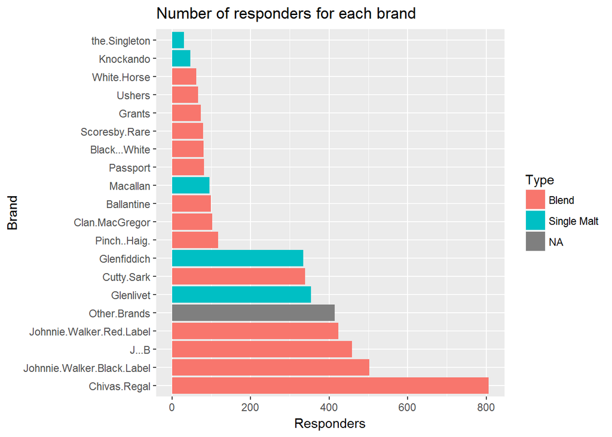

```r
responders1<-responders[-6,]
brand_orderdesc2 <- responders1 %>% arrange(desc(Responders))
data3=responders1
data3$Brand<-factor(responders1$Brand,levels=brand_orderdesc2$Brand)

ggplot(data=data3,aes(x=Brand,y=Responders,fill=Type))+geom_bar(stat='identity')+ coord_flip()+ggtitle("Number of responders for each brand")
```

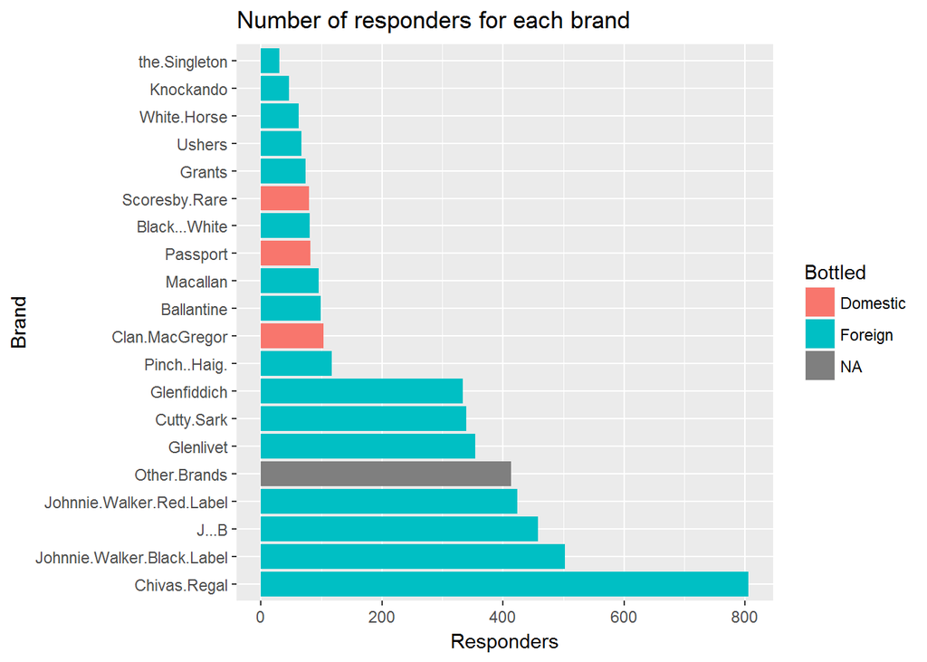

```r
ggplot(data=data3,aes(x=Brand,y=Responders,fill=Bottled))+geom_bar(stat='identity')+ coord_flip()+ggtitle("Number of responders for each brand")
```

1. I think it is best to order the brands by their number of respondents. It becomes easier to find a relationship between two brands.
2. Other brands could be defined as the ones having significantly low res ponders. We can see that the number of res ponders drop drastically for Pinch Haig and after that. **Pinch Haig has 117** respondents. Hence, we can use this as cut-off to define big and small brands.
3. The two plots show the type and bottled location of the brands.
4. Would call it **Whisky** because the major brands in this dataset are foreign where the ‘Whisky’ spelling is used. ‘Wishkey’ is used in US and lot of these brands are Scottish who use ‘Whisky’. Assuming that the dataset is from USA.

# Chapter 5, Question 8

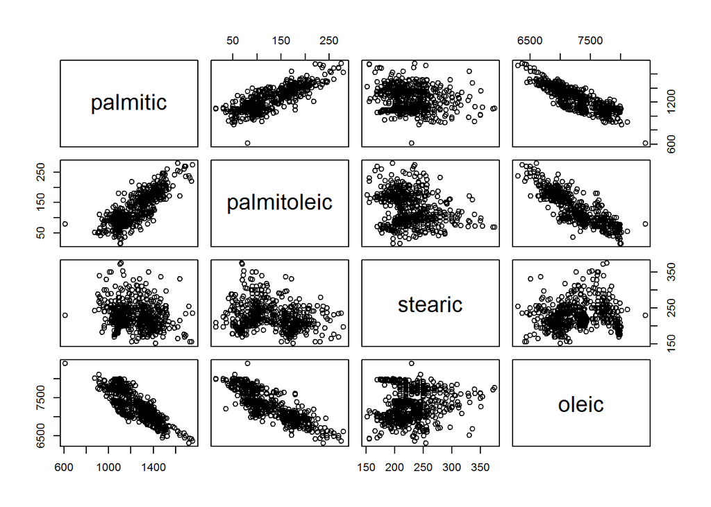

```r
data(olives)
olives=olives

#Plotting scatter plots of 4 variables at a time so that the plots are readable
plot(olives[,3:6],pch=1)
```

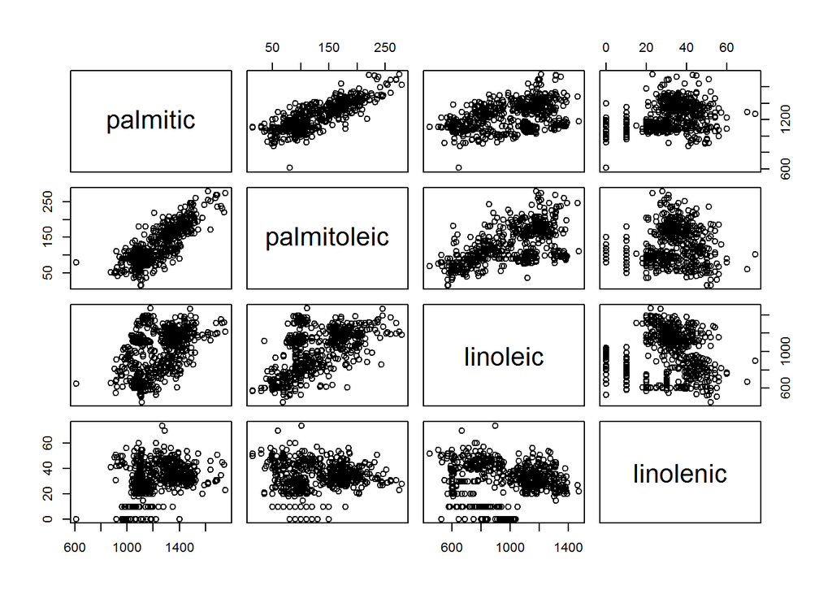

```r
plot(olives[,c(3,4,7,8)],pch=1)
```

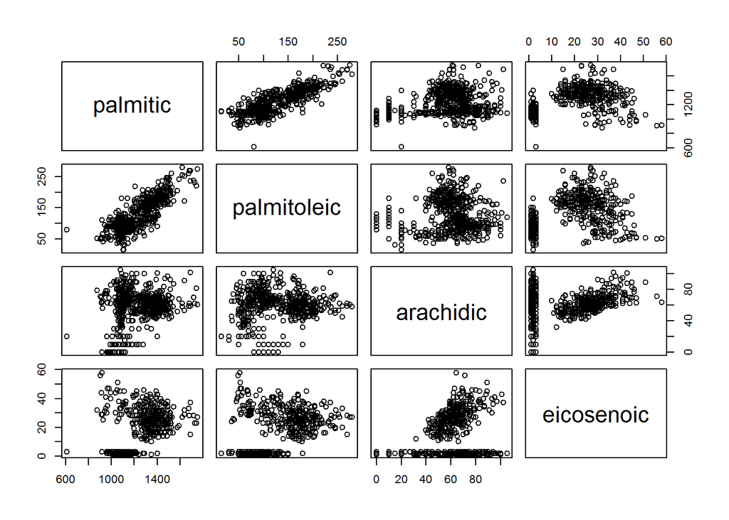

```r
plot(olives[,c(3,4,9,10)],pch=1)
```

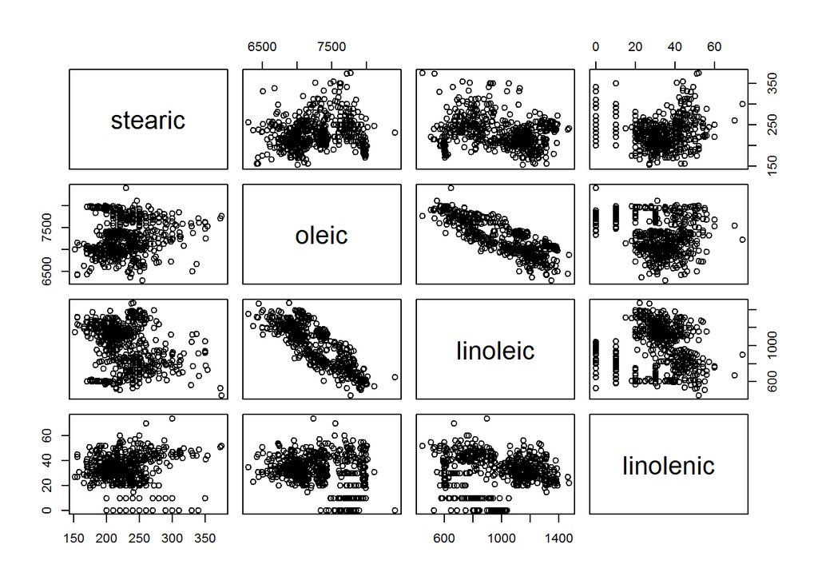

```r
plot(olives[,c(5,6,7,8)],pch=1)
```

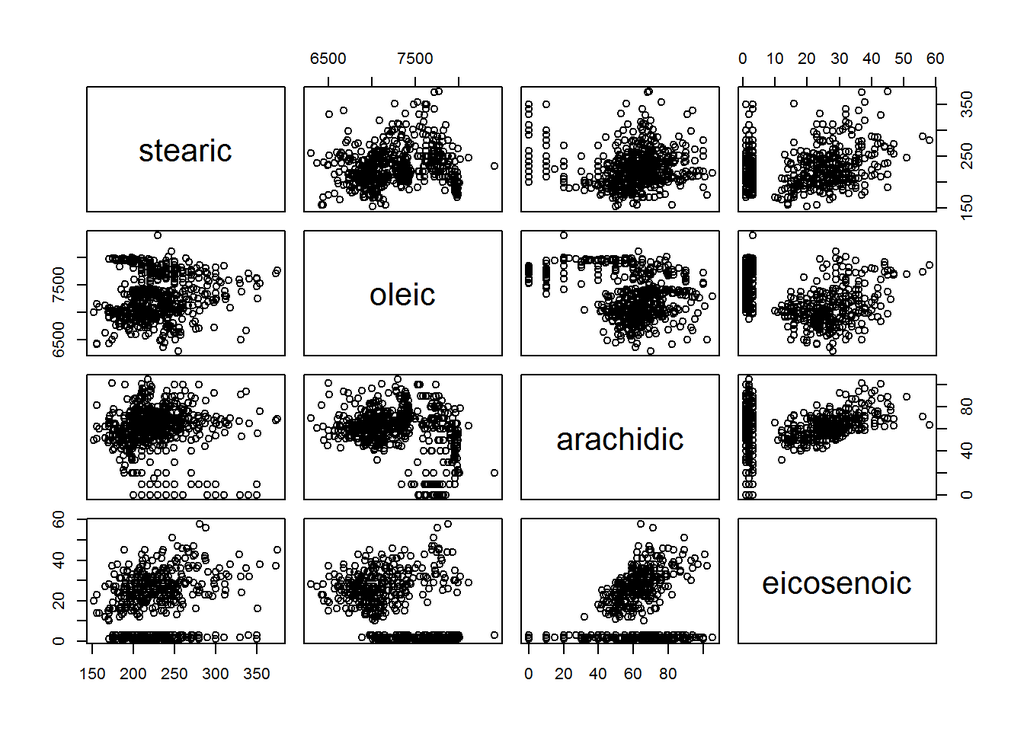

```r
plot(olives[,c(5,6,9,10)],pch=1)
```

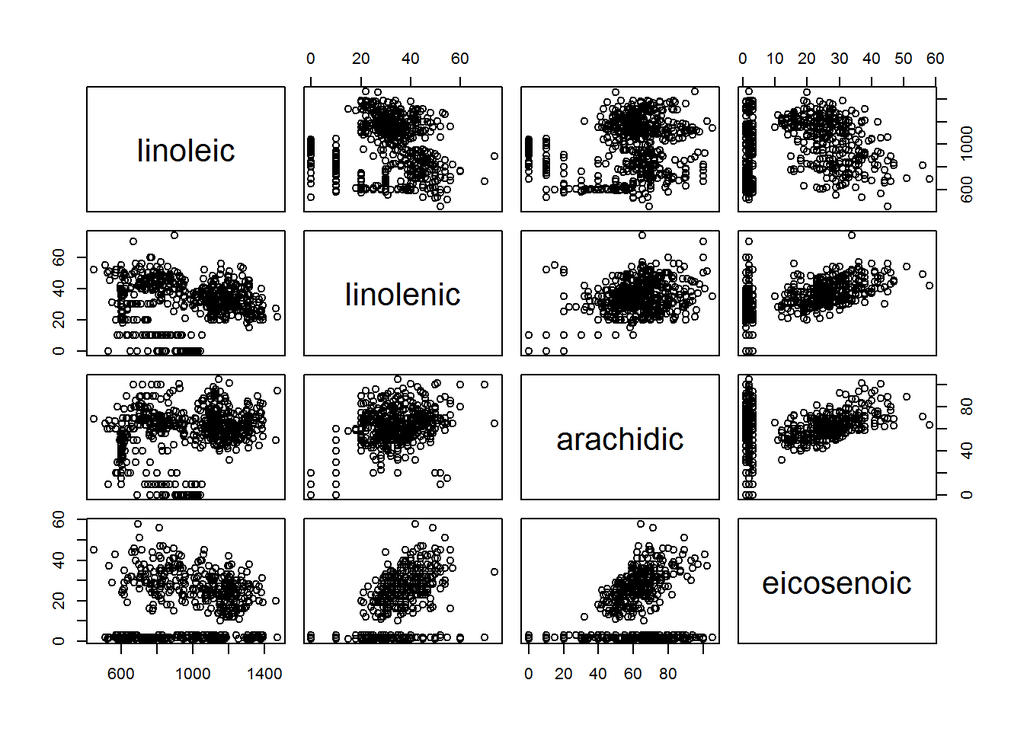

```r
plot(olives[,c(7,8,9,10)],pch=1)
```

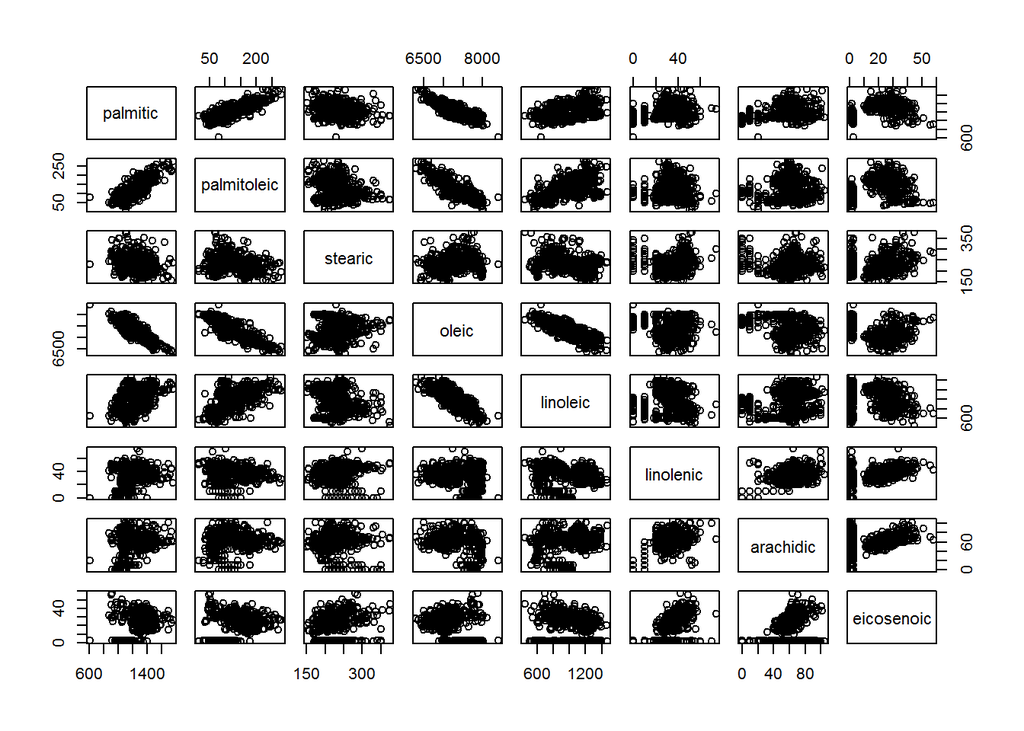

```r
plot(olives[,3:10],pch=1)
```

Plotting scatter plots of 4 variables at a time so that the plots are readable.

1. **Strong positive association:** palmitic & pamitoleic, palmitic & linoleic, pamitoleic & linoleic. Arachidic and eicosenic also show some positive association. But, there are many data-points where value for eicosenic is low (1 to 3) for different values of arachidic. Same is true for Linolenic and eicoseoic.

**Strong negative association:** palmitic & oleic, pamitoleic & oleic,oleic and linoeic.

2. **Outliers and other features:** Palmitic has one outlier which can be clearly seen. Stearic also has some outliers. Linolenic and eicosenoic have a couple of outliers on the higher side. Many of the fatty acids have high occurrences of low value and these low values are spread across for different values of other fatty acids. This leads to a clearly standing out groups of points which form a straight line parallel to X/Y-axis depending on which axis these fatty acids are plotted on. Linolenic, eicosenoic and arachidic show such characteristic.

# Chapter 5, Question 10

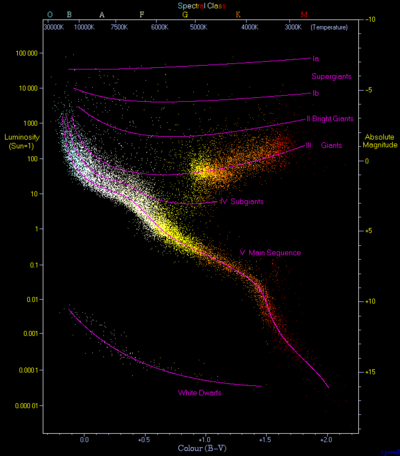

HR plot

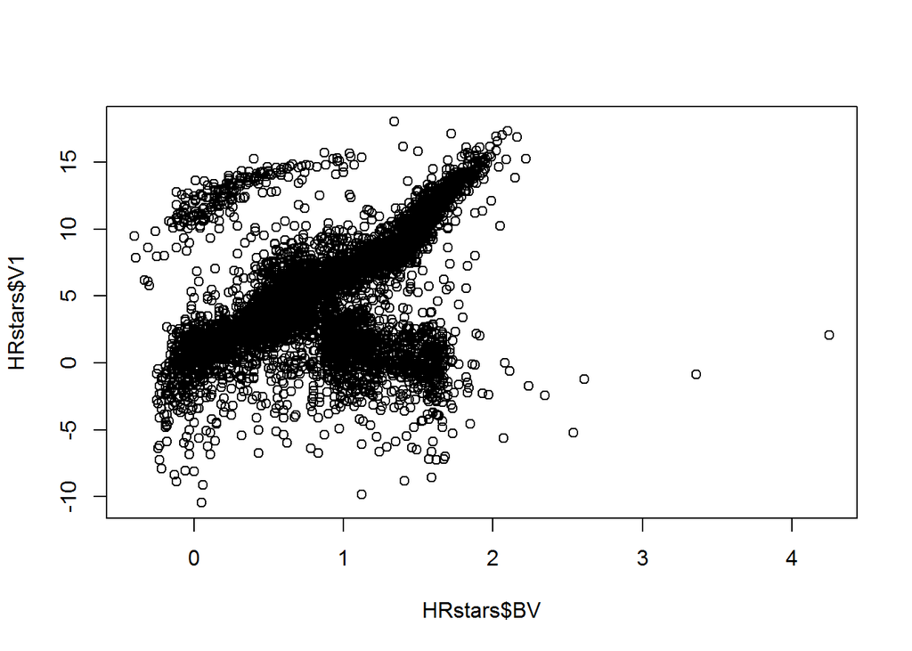

```r
library(GDAdata)
#data(HRstars)
HRstars=HRstars
HRstars$V1=HRstars$V+5*(1+log10(HRstars$Para))
plot(HRstars$BV,HRstars$V1)
```

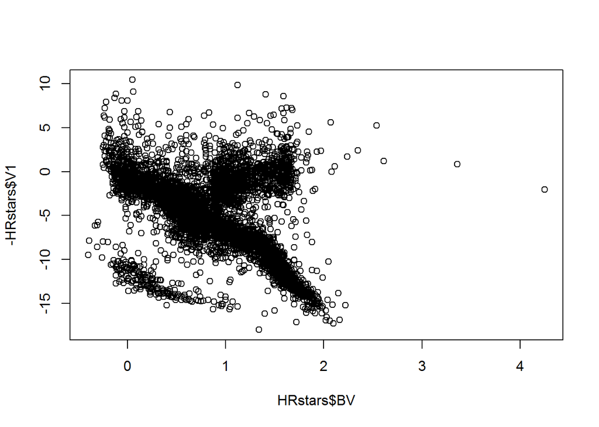

```r
plot(HRstars$BV,-HRstars$V1)
```

1. The plots look similar to each other on flipping the values of V in data. But, the points are not so well separated as can be seen in the original HR plot.
2. The stars for which we don’t have appropriate data or are unable to get the correct data, are less likely to be used.
3. We can clearly see three distinct groups of stars in the plot. We can color them differently by modifying the data appropriately. We can also add legends to explain what each of the group is. We can reduce the size of dots to make it more readable.

# Chapter 6, Question 5

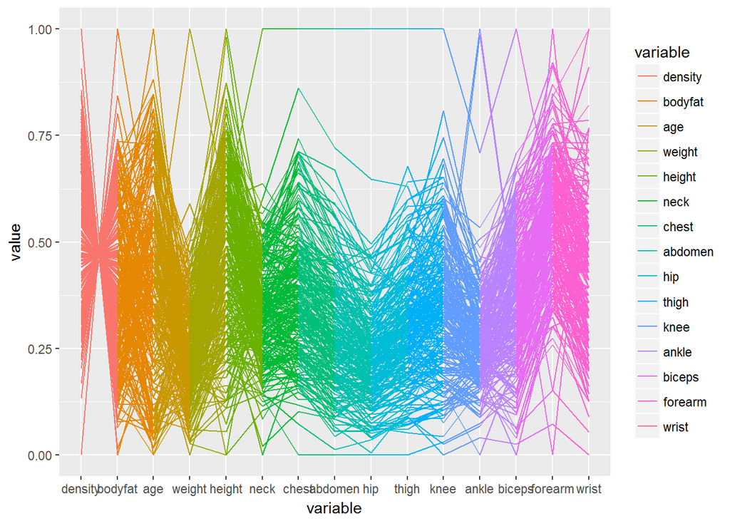

```r
load("C:/Users/Abhay Pawar/Downloads/wine.rda")
load("C:/Users/Abhay Pawar/Downloads/bodyfat.rda")
bodyfat1=bodyfat

for (i in 1:length(colnames(bodyfat1))){
  max=max(bodyfat1[,i])
  min=min(bodyfat1[,i])
  bodyfat1[,i]=(bodyfat1[,i]-min)/(max-min)
}

bodyfat1$id=0*bodyfat1$bodyfat
for (i in 1:length(bodyfat1$bodyfat)){
  bodyfat1$id[i]=i
}
bodyfat_tidy <- melt(bodyfat1, id=c("id"))
ggplot(bodyfat_tidy, aes(variable, value, group = id,color=variable)) +
    geom_line()
```

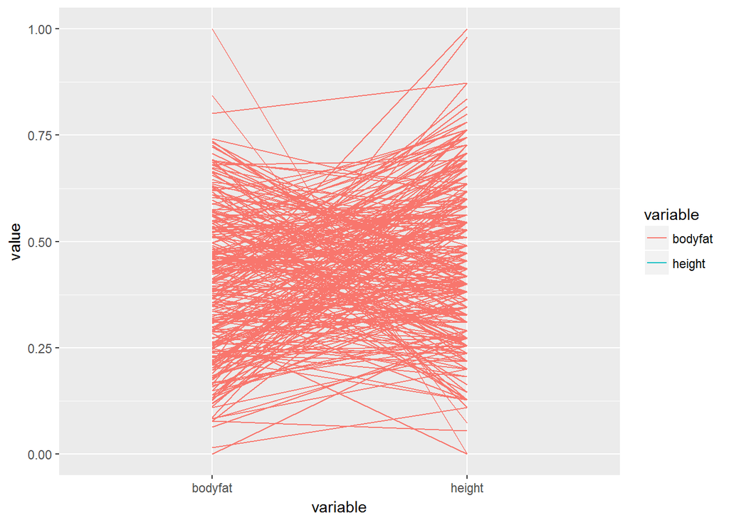

```r
ggplot(bodyfat_tidy[bodyfat_tidy$variable=="height" | bodyfat_tidy$variable=="bodyfat",], aes(variable, value, group = id,color=variable)) +
    geom_line()
```

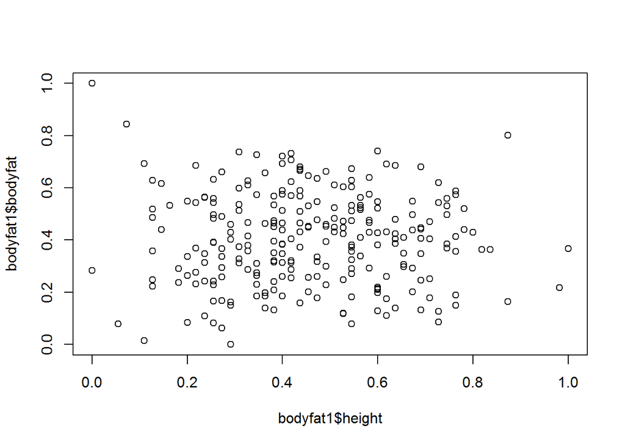

```r
plot(bodyfat1$height,bodyfat1$bodyfat)
```

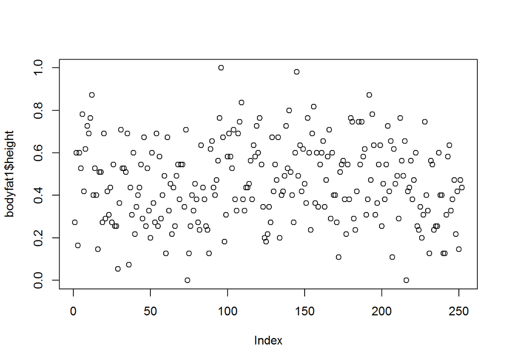

```r
plot(bodyfat1$height)
```

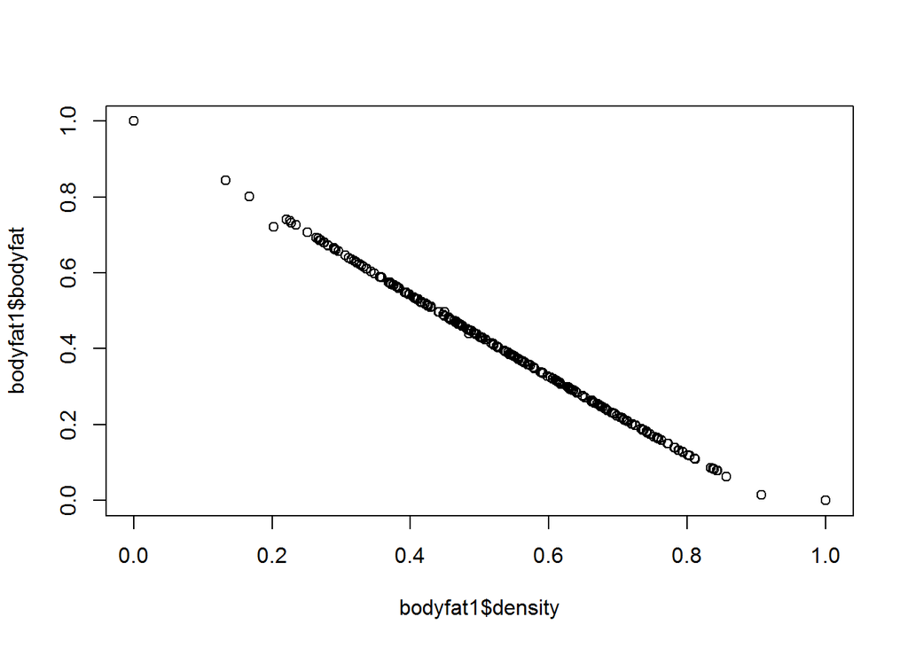

```r
plot(bodyfat1$density,bodyfat1$bodyfat)
```

The PCP is a scaled parallel coordinate plot. (a) There are many outliers on both sides (Value=0 and value=1). We can also see some individuals consistently having extreme values. Eg. We see a line at 1 from neck to knee which is a same person. We see similar individuals with value=0 for many parameters.

2. On plotting the parallel coordinate plot for bodyfat and height, we can see that there is not much correlation between these. Same can be seen from the scatter plot of the two variables. There are also a couple of records with zero/very low height which is unlikely.
3. Density and bodyfat have high negative correlation. We can clearly see that individuals with low density have high body fat and vice-verse. Same can be seen more clearly from the scatter plot.
4. The ordering makes it difficult to make much sense out of the data. For the purpose of building a multiple linear regression model, they could be ordered on the basis of how correlated the variables are with bodyfat. They could also be ordered from head to toe to clearly visualize which body parts matter more.

# Chapter 6, Question 7

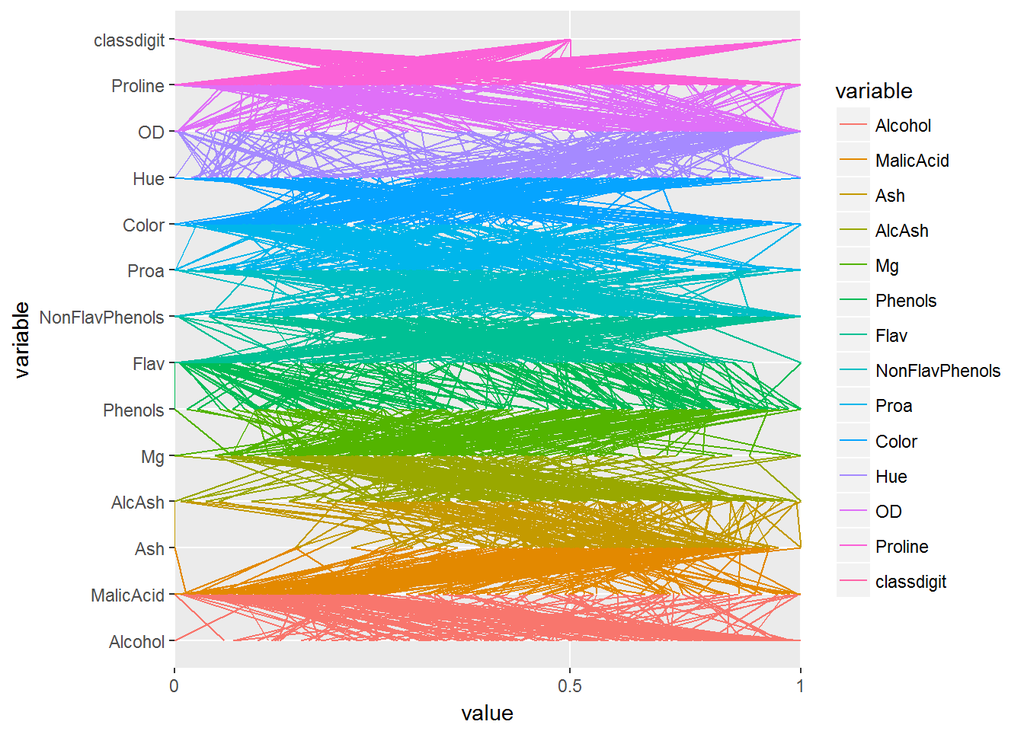

```r
wine1=wine
wine1$classdigit=as.numeric(wine1$classdigit)
for (i in 1:14){
  max=max(wine1[,i])
  min=min(wine1[,i])
  wine1[,i]=(wine1[,i]-min)/(max-min)
}
for (i in 1:length(wine1$Alcohol)){
  wine1$id[i]=i
}
# Plotting inidividual pcp for each variable so that it can be read well
wine_tidy <- melt(wine1, id=c("id"))
ggplot(wine_tidy[wine_tidy$variable!="class",], aes(variable, value, group = id,color=variable)) + geom_line()+ scale_y_discrete(breaks=c("0","0.5","1"))+coord_flip()
```

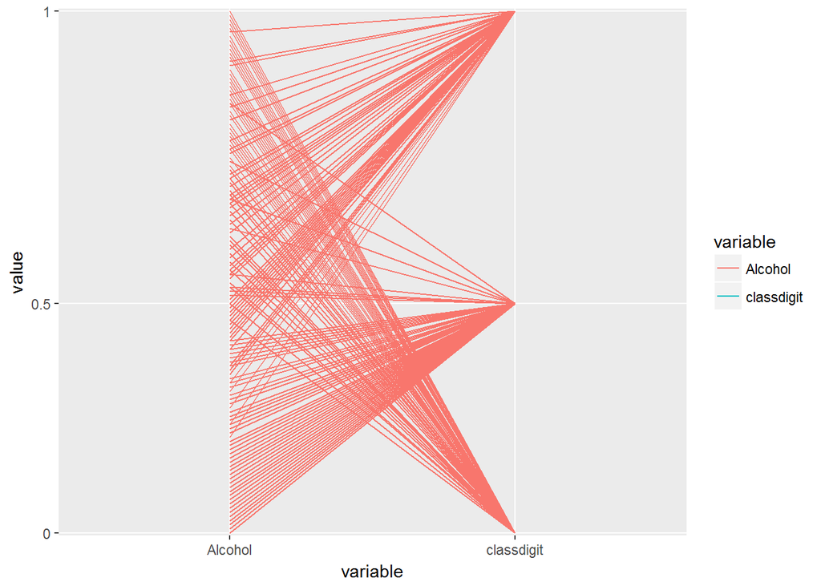

```r
ggplot(wine_tidy[wine_tidy$variable=="classdigit" | wine_tidy$variable=="Alcohol",], aes(variable, value, group = id,color=variable)) + geom_line()+ scale_y_discrete(breaks=c("0","0.5","1"))
```

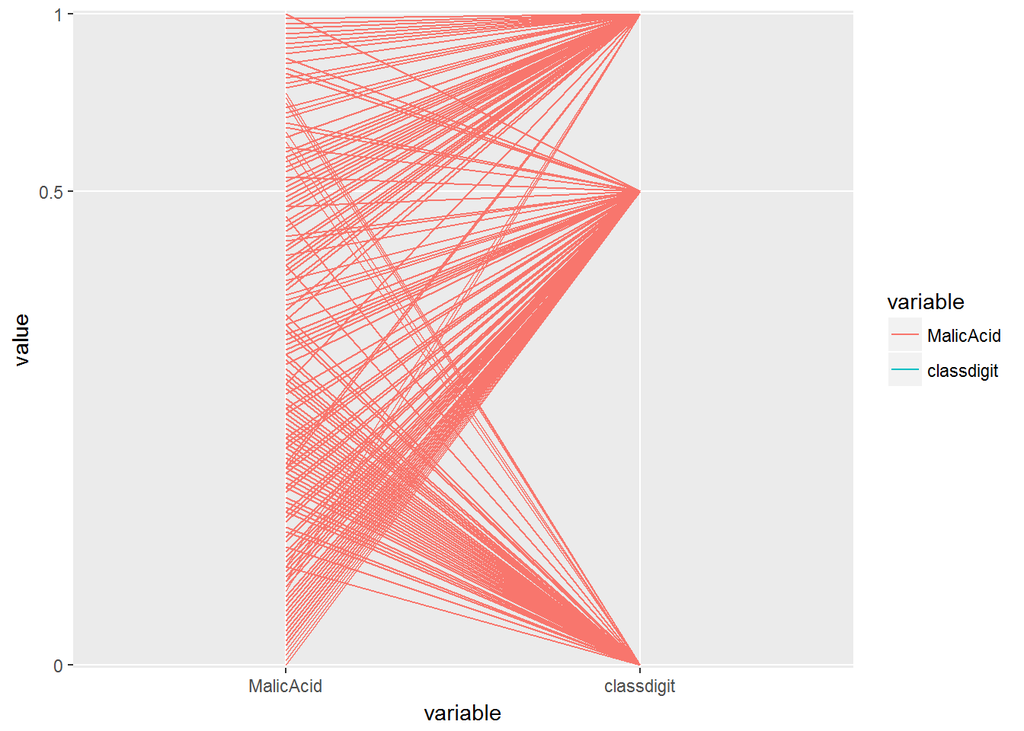

```r
ggplot(wine_tidy[wine_tidy$variable=="classdigit" | wine_tidy$variable=="MalicAcid",], aes(variable, value, group = id,color=variable)) + geom_line()+ scale_y_discrete(breaks=c("0","0.5","1"))
```

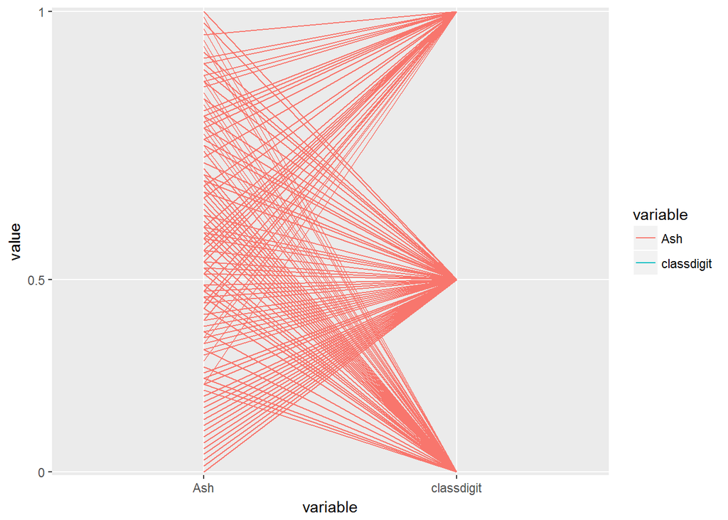

```r
ggplot(wine_tidy[wine_tidy$variable=="classdigit" | wine_tidy$variable=="Ash",], aes(variable, value, group = id,color=variable)) + geom_line()+ scale_y_discrete(breaks=c("0","0.5","1"))
```

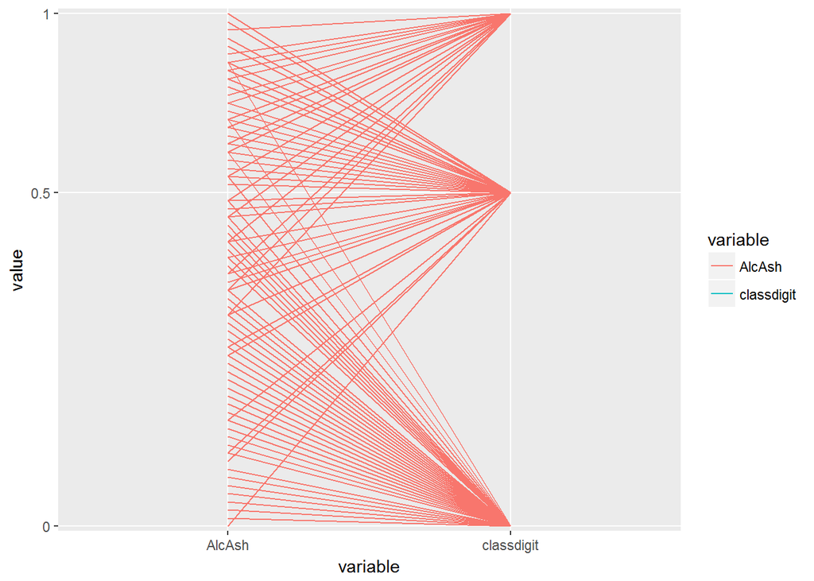

```r
ggplot(wine_tidy[wine_tidy$variable=="classdigit" | wine_tidy$variable=="AlcAsh",], aes(variable, value, group = id,color=variable)) + geom_line()+ scale_y_discrete(breaks=c("0","0.5","1"))
```

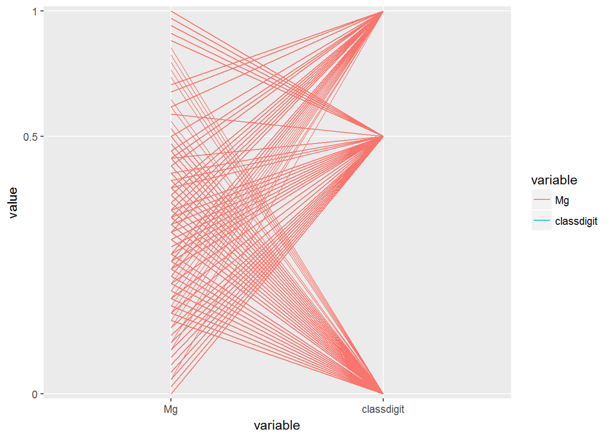

```r
ggplot(wine_tidy[wine_tidy$variable=="classdigit" | wine_tidy$variable=="Mg",], aes(variable, value, group = id,color=variable)) + geom_line()+ scale_y_discrete(breaks=c("0","0.5","1"))
```

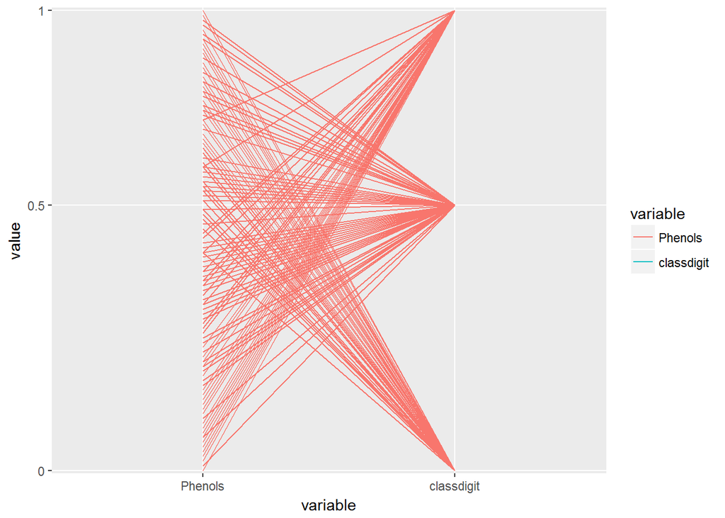

```r
ggplot(wine_tidy[wine_tidy$variable=="classdigit" | wine_tidy$variable=="Phenols",], aes(variable, value, group = id,color=variable)) + geom_line()+ scale_y_discrete(breaks=c("0","0.5","1"))
```

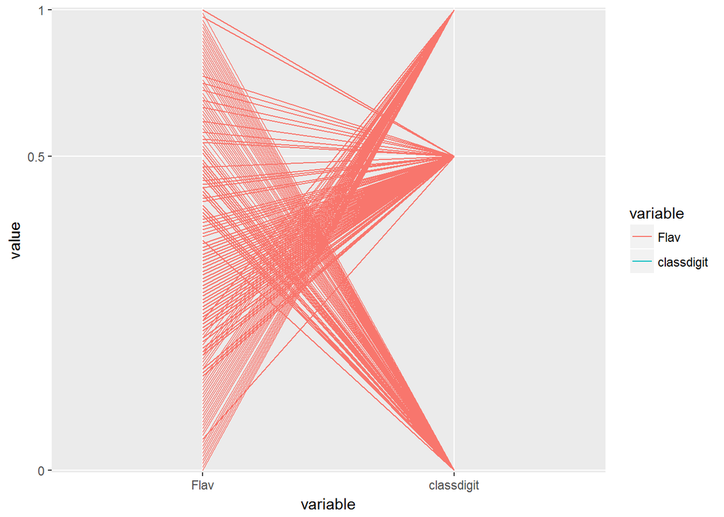

```r
ggplot(wine_tidy[wine_tidy$variable=="classdigit" | wine_tidy$variable=="Flav",], aes(variable, value, group = id,color=variable)) + geom_line()+ scale_y_discrete(breaks=c("0","0.5","1"))
```

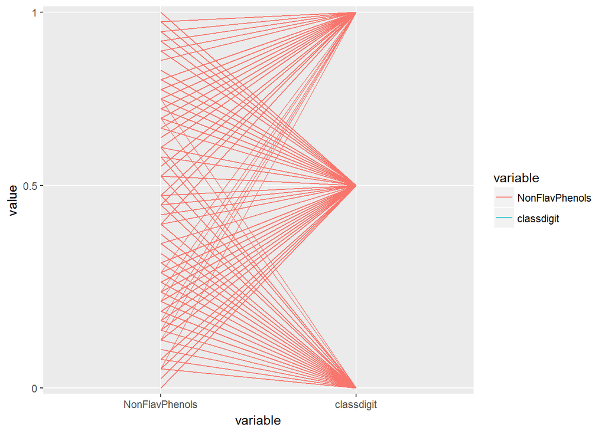

```r
ggplot(wine_tidy[wine_tidy$variable=="classdigit" | wine_tidy$variable=="NonFlavPhenols",], aes(variable, value, group = id,color=variable)) + geom_line()+ scale_y_discrete(breaks=c("0","0.5","1"))
```

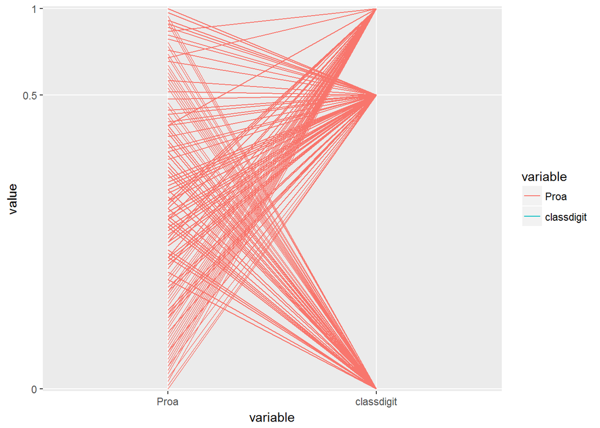

```r
ggplot(wine_tidy[wine_tidy$variable=="classdigit" | wine_tidy$variable=="Proa",], aes(variable, value, group = id,color=variable)) + geom_line()+ scale_y_discrete(breaks=c("0","0.5","1"))
```

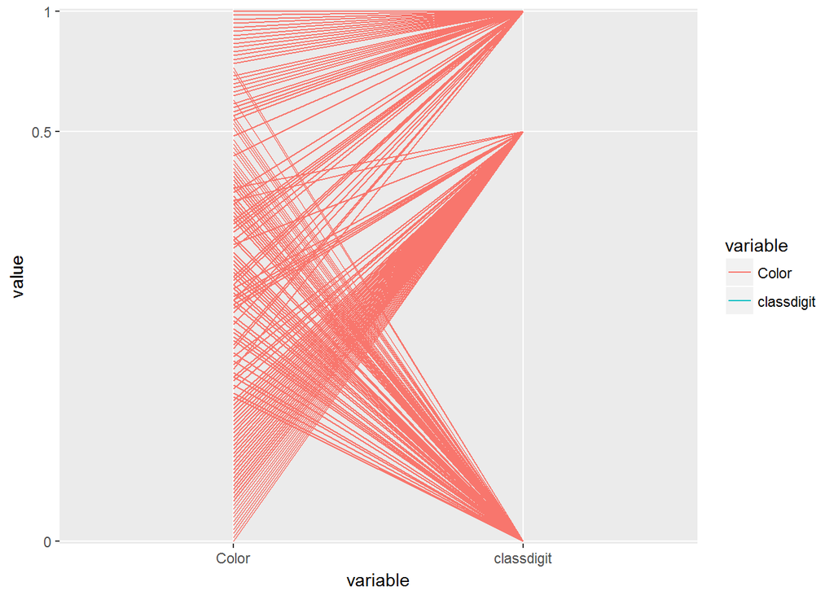

```r
ggplot(wine_tidy[wine_tidy$variable=="classdigit" | wine_tidy$variable=="Color",], aes(variable, value, group = id,color=variable)) + geom_line()+ scale_y_discrete(breaks=c("0","0.5","1"))
```